# data analysis

punyung

2023-07

## Mutation data analysis

Loading mutation data

```r
options (warn = -1)
data_mut <- readRDS("data/mutations_sclc_ucologne_2015.rds")
```

```r
# Add a column for ID
data_mut$ID <- paste(data_mut$chrom,data_mut$start_pos,data_mut$end_pos,sep=":")
data_mut_sub <- data_mut[,c(17,1)]
dim(data_mut_sub)
```

```
## [1] 38646     2
```

```r
data_mut_uni <- data_mut_sub[!duplicated(data_mut_sub),] # Remove duplicate variants
gene_mut_freq <- as.data.frame(table(data_mut_uni$gene))
gene_mut_freq_sort <- gene_mut_freq[order(gene_mut_freq$Freq,decreasing=T),]
gene_top10 <- gene_mut_freq_sort[1:10,] # 10 most frequently mutated genes
# Identify samples whose mutation count is in 80 to 90 percentile
sample_mut <- data_mut[,c(17,11)]
sample_mut_uni <- sample_mut[!duplicated(sample_mut),]
sample_mut_freq <- as.data.frame(table(sample_mut_uni$sample_id))
quantile(sample_mut_freq$Freq,c(0.8,0.9))
```

```
##   80%   90%
## 479.0 625.8
```

2.Categorize variants based on their expected effects using the data/mutation_effects.tsv table.

```r
library(dplyr)
VarEffect <- read.table("data/mutation_effects.tsv",header = T)
data_var <- data_mut[,c("gene","variant_class")]
data_var_eff <- left_join(data_var,VarEffect,by="variant_class")
head(data_var_eff)
```

```
##     gene          variant_class    effect
## 1 MARCH1      Missense_Mutation uncertain
## 2 MARCH1                 Silent   neutral
## 3 MARCH1      Missense_Mutation uncertain
## 4 MARCH1      Missense_Mutation uncertain
## 5 MARCH1 Translation_Start_Site uncertain
## 6 MARCH2      Missense_Mutation uncertain
```

```r
data_var_eff <- data_var_eff[data_var_eff$effect %in% c("neutral","loss_of_function"),] # retaining the effect is either "neutral" or "loss-of-function
head(data_var_eff)
```

```
##      gene     variant_class           effect
## 2  MARCH1            Silent          neutral
## 7  MARCH4            Silent          neutral
## 10 MARCH5 Nonsense_Mutation loss_of_function
## 11 MARCH6            Silent          neutral
## 14 MARCH6       Splice_Site loss_of_function
## 16 MARCH8            Silent          neutral
```

3.Implement a statistical test that determines whether a gene has a significantly higher proportion of loss-of-function mutations (excluding mutations with uncertain effects), compared to other genes.

```r
# calculate the observed counts of loss-of-function and other mutation
counts_var <- table(data_var_eff$gene,data_var_eff$effect)
head(counts_var)
```

```
##
##           loss_of_function neutral
##   A1CF                   0       1
##   A2ML1                  0       2
##   A4GALT                 0       1
##   A4GNT                  1       0
##   AACS                   1       0
##   AADACL4                1       0
```

```r
# Perform the chi-square test for each gene
gene_results_pval <- apply(counts_var,1,function(row){
  chisq.test(row)$p.value
})

gene_results <- apply(counts_var,1,function(row){
  chisq.test(row)
})

# value for multiple testing, using method fdr
adjusted_pvalues <- p.adjust(gene_results_pval,method = "fdr")
head(adjusted_pvalues)
```

```
##      A1CF     A2ML1    A4GALT     A4GNT      AACS   AADACL4
## 0.3816281 0.3816281 0.3816281 0.3816281 0.3816281 0.3816281
```

4.Identify candidate tumour suppressor genes using this statistical test, adjusting for multiple hypothesis testing.

```r
# calculate the effect size of genes
relative_risks <- numeric(length=nrow(counts_var))
for(i in 1:nrow(counts_var)){
  gene <- rownames(counts_var)[i]
  loss_of_function_count <- counts_var[i,1]
  neutral_count <- counts_var[i,2]

  # calculate relative risks
  Risk1 <- loss_of_function_count / (loss_of_function_count+neutral_count)
  Risk2 <- sum(counts_var[,"loss_of_function"]) / sum(counts_var[,"loss_of_function"] + counts_var[,"neutral"])
  relative_risks[i] <- Risk1/Risk2
}

result_df <- data.frame(gene_symbol = names(gene_results),
                        effect_size = relative_risks,
                        p_value = gene_results_pval,
                        q_value = adjusted_pvalues)
# Set a significant threshold
gene_tumoursupress <- result_df[result_df$q_value<0.05,]
head(gene_tumoursupress)
```

```
##       gene_symbol effect_size      p_value      q_value
## IGFN1       IGFN1    0.000000 4.592834e-06 1.106414e-02
## RB1           RB1    3.008977 3.223742e-17 2.329798e-13
## TP53         TP53    3.087132 1.973175e-09 7.130069e-06
```

5.Gene function Description

- *IGFN1:* IGFN1 is a eukaryotic translation elongation factor 1A (eEF1A) binding protein and expressed in many ocular tissues such as RPE, retinal foveal and macula, and lens. Frequent IGFN1 mutation is detected in metastatic breast cancer, the disease which leads to the poor prognosis of patients.IGFN1 is not prognostic in lung cancer. [1]-[3]
- *RB1:* The RB1 protein, regulates the cell cycle by inhibiting cell division and promoting cell cycle arrest. Mutations in the RB1 gene can lead to loss of pRB function, resulting in uncontrolled cell proliferation and an increased risk of developing cancer. The loss of RB1 can efficiently transform neuroendocrine and SPC-expressing cells leading to small cell lung cancer(SCLC), albeit SPC-expressing cells at a lesser efficiency.[4]-[7]
- *TP53:* TP53 plays a critical role in preventing cancer development by regulating cell growth, DNA repair, and programmed cell death (apoptosis). Mutations in TP53 are found in a wide range of cancers and are associated with the loss of its tumor suppressor function, resulting in uncontrolled cell growth and increased susceptibility to cancer development. In the context of SCLC, the inactivation of TP53 is considered a critical and initiating molecular event. This inactivation primarily affects normal neuroendocrine (NE) cells expressing ASCL1, which are predominantly located in larger airways. In some instances, the inactivation events may also involve derivatives of other multipotent cells.[7]-[10]
- Reference:
- [1]Wen, Xiaofeng et al. “Association of IGFN1 variant with polypoidal choroidal vasculopathy.” The journal of gene medicine vol. 20,2-3 (2018): e3007. doi:10.1002/jgm.3007
- [2]Lefebvre, Celine et al. “Mutational Profile of Metastatic Breast Cancers: A Retrospective Analysis.” PLoS medicine vol. 13,12 e1002201. 27 Dec. 2016, doi:10.1371/journal.pmed.1002201
- [3]Sjöstedt, Evelina et al. “An atlas of the protein-coding genes in the human, pig, and mouse brain.” Science (New York, N.Y.) vol. 367,6482 (2020): eaay5947. doi:10.1126/science.aay5947
- [4]Sutherland, Kate D et al. “Cell of origin of small cell lung cancer: inactivation of Trp53 and Rb1 in distinct cell types of adult mouse lung.” Cancer cell vol. 19,6 (2011): 754-64. doi:10.1016/j.ccr.2011.04.019
- [5]Fiorentino FP, Tokgün E, Solé-Sánchez S, et al. Growth suppression by MYC inhibition in small cell lung cancer cells with TP53 and RB1 inactivation. Oncotarget. 2016;7(21):31014-31028. doi:10.18632/oncotarget.8826
- [6]Knudsen, Erik S et al. “Cell Cycle and Beyond: Exploiting New RB1 Controlled Mechanisms for Cancer Therapy.” Trends in cancer vol. 5,5 (2019): 308-324. doi:10.1016/j.trecan.2019.03.005
- [7]Gazdar, Adi F et al. “Small-cell lung cancer: what we know, what we need to know and the path forward.” Nature reviews. Cancer vol. 17,12 (2017): 725-737. doi:10.1038/nrc.2017.87
- [8]Offin, Michael et al. “Concurrent RB1 and TP53 Alterations Define a Subset of EGFR-Mutant Lung Cancers at risk for Histologic Transformation and Inferior Clinical Outcomes.” Journal of thoracic oncology : official publication of the International Association for the Study of Lung Cancer vol. 14,10 (2019): 1784-1793. doi:10.1016/j.jtho.2019.06.002
- [9]Bebber, Christina M et al. “Ferroptosis response segregates small cell lung cancer (SCLC) neuroendocrine subtypes.” Nature communications vol. 12,1 2048. 6 Apr. 2021, doi:10.1038/s41467-021-22336-4
- [10]Wang, Zilu et al. “Should mutant TP53 be targeted for cancer therapy?.” Cell death and differentiation vol. 29,5 (2022): 911-920. doi:10.1038/s41418-022-00962-9

## Transcriptomic data normalization

Loading transcriptomic data

```r
rm(list=ls())
data_trans <- readRDS("data/expr_sclc_ucologne_2015.rds")
```

1.Perform an appropriate log transformation on the data.

```r
data_trans_log <- log(data_trans+1)
#head(data_trans_log)
dim(data_trans_log)
```

```
## [1] 18807    81
```

2.Implement a median polish algorithm from scartch.

```r
# initial value
rowmedian <- 0.1
colmedian <- 0.1
i <- 0　# iteration
data_trans_mp <- data_trans_log
#all(rowmedian==0)==FALSE
while(i < 11){
# find the row medians for each row
rowmedian <- apply(data_trans_mp,1,median)
# subtract that median number from all the elements of each row
data_trans_mp <- data_trans_mp - rowmedian
# identify the median of the column
colmedian <- apply(data_trans_mp,2,median)
# subtract the column median from all the elements
data_trans_mp <- data_trans_mp - colmedian
# repeat this progress until we coverge to have medians of zero across the rows and columns
i <- i+1 # calculate the number of interations
}
```

3.Compare the residuals of algorithm and stats::medpolish  
I try to use density plots and histograms to compare the distribution of the residuals between algorithm and stats::medpolish. It’s found that the distribution processed by the medpolish algorithm is unimodal. It shows that the expression levels of most genes are concentrated in a specific level range after normalization.

```r
data_trans_mp_re1 <- data_trans_log - data_trans_mp # residuals from my own algorithm
data_trans_mp_re2 <- stats::medpolish(data_trans_log)$residuals # residuals from medpolish function
```

```
## 1: 450631.8
## Final: 450534
```

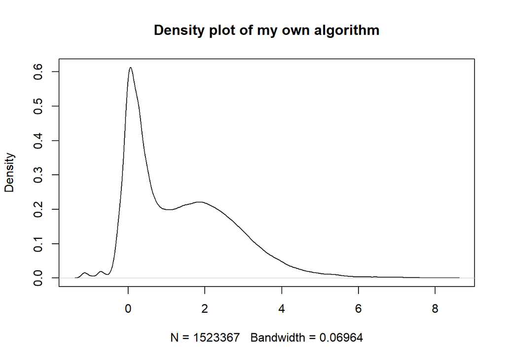

```r
# Use Kernel density estimation to visualize the distribution of residuals
a1 <- plot(density(data_trans_mp_re1),main="Density plot of my own algorithm")
```

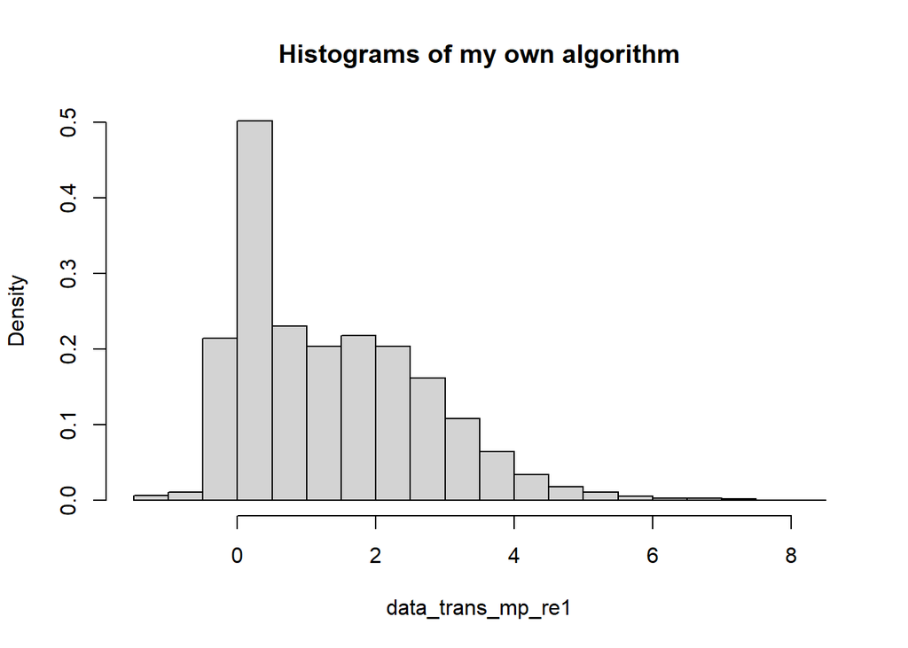

```r
a2 <- hist(data_trans_mp_re1,freq=F,main= "Histograms of my own algorithm")
```

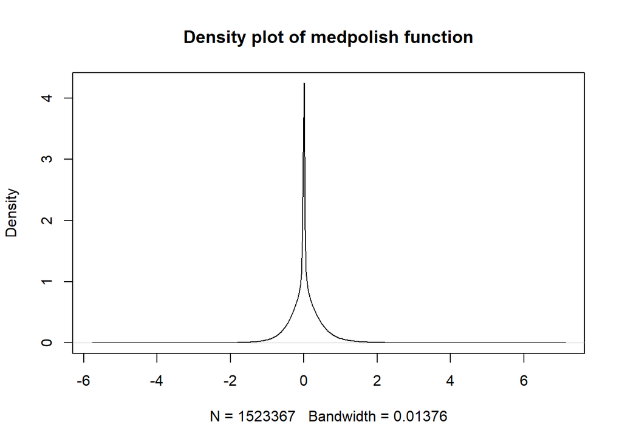

```r
b1 <- plot(density(data_trans_mp_re2),main="Density plot of medpolish function")
```

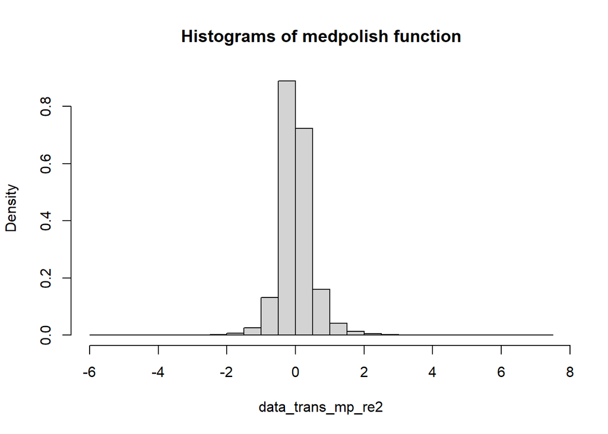

```r
b2 <- hist(data_trans_mp_re2,freq=F,main="Histograms of medpolish function")
```

4.Plot heatmaps of the results before and after median polish

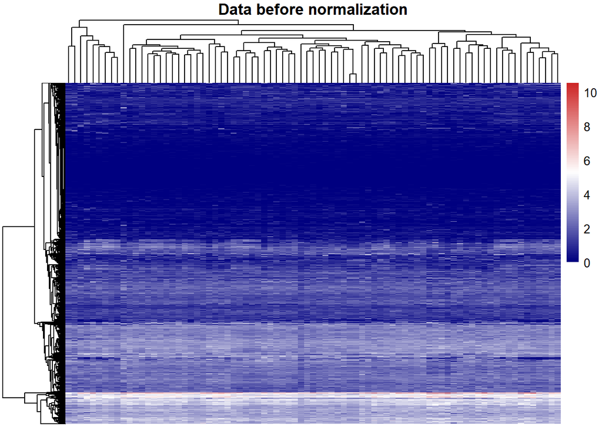

```r
library(pheatmap)
library(ggplotify)
p1 <- pheatmap(data_trans_log,
                 cluster_rows = T,
                 cluster_cols = T,
                 show_rownames = F,
                 show_colnames = F,
                 scale = "none",

                 color =colorRampPalette(c("navy", "white","firebrick3"))(100),
                 main = "Data before normalization")
```

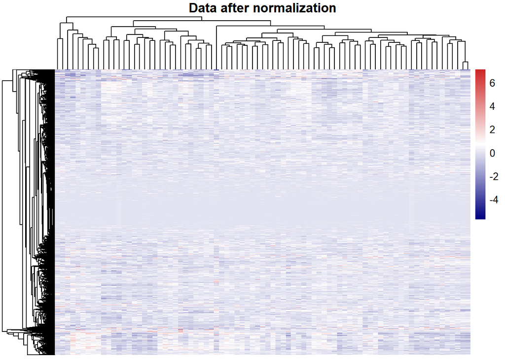

```r
p1 <- as.ggplot(p1)
p2 <- pheatmap(data_trans_mp_re2,
                 cluster_rows = T,
                 cluster_cols = T,
                 show_rownames = F,
                 show_colnames = F,
                 scale = "none",
                 color =colorRampPalette(c("navy", "white","firebrick3"))(100),
                 main = "Data after normalization")
```

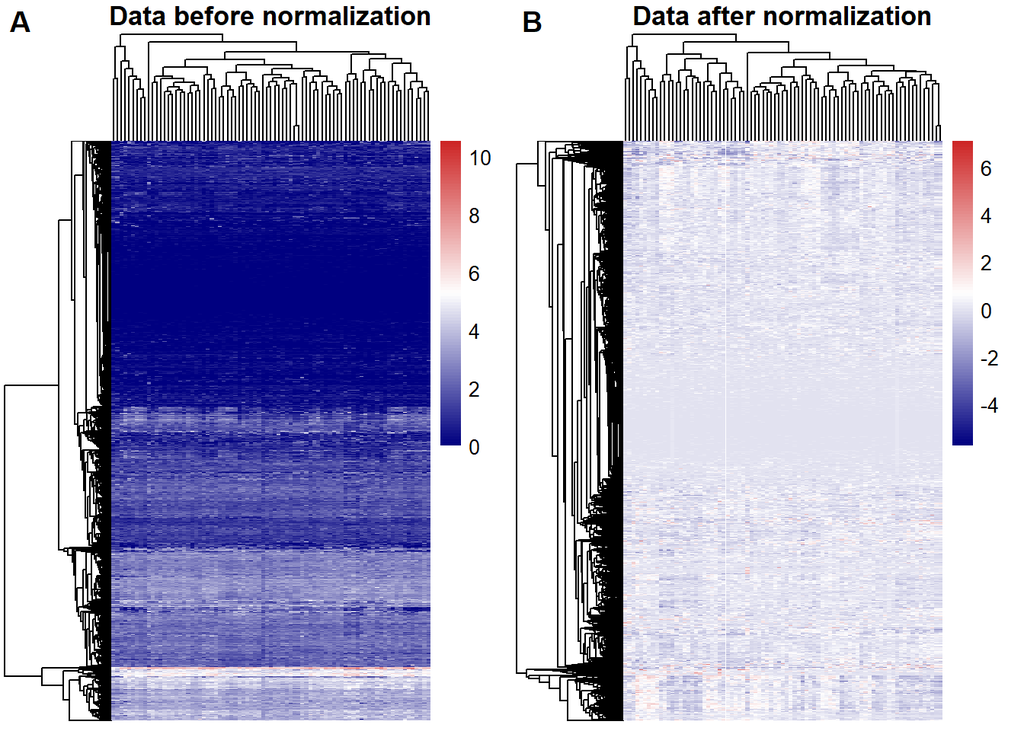

```r
p2 <- as.ggplot(p2)
library(cowplot)
plot_grid(p1,p2,labels=c("A","B"),nrow=1,ncol=2) # Stitch two images together
```

5.Output the median polished residual matrix as the normalized transcriptomic data

```r
write.table(data_trans_mp_re2,file="normalized transcriptomic data",sep="",row.names=T,col.names=T)
```

## Differential gene expression analysis

Data preprocessing

```r
library(readr)
data_clinical <- read_tsv("data/pheno_sclc_ucologne_2015.tsv")
```

1.Define two groups of tumours: early stage (I-II) vs advanced stage (III-IV)

```r
group_early <- data_clinical[which(data_clinical$uicc_tumor_stage=="I" | data_clinical$uicc_tumor_stage=="II"),]
group_advanced <- data_clinical[which(data_clinical$uicc_tumor_stage=="III" | data_clinical$uicc_tumor_stage=="IV"),]
group <- rbind(group_early,group_advanced)
#group$patient_id
# Filtering out samples in the clinical data that cannot be matched with the gene expression matrix
col <- colnames(data_trans) # sample name of expression dataset
match_re <- na.omit(match(group$patient_id,col)) # Remove samples not included in gene expression data
count_DE <- data_trans[,match_re] # matrix for differential gene expression analysis
group_sub <- group[match(colnames(count_DE),group$patient_id),]
group_DE <- c(rep("early",2),rep("advanced",9)) # Rename the group
```

2.Identify differentially expressed genes Perform differential gene expression analysis using the edgeR package.

```r
library(edgeR)
y <- DGEList(counts=count_DE,group = group_DE) # create a DGEList object
y <- calcNormFactors(y, method="TMM") # compute relative scaling factors for libraries
design <- model.matrix(~as.factor(group_DE)) # create design matrix with intercept
y <- estimateDisp(y, design) # Estimate dispersion
fit <- glmFit(y, design) # Fit genewise negatvie binomial models
lrt <- glmLRT(fit, coef=2)
de_res <- topTags(lrt, n=nrow(count_DE))$table # return top 10 differential expressed gene
de_called_fdr <- rownames(de_res)[de_res$FDR < 0.01] # cutoff=1%
cat("The differential genes are as follows:",de_called_fdr)
```

```
## The differential genes are as follows: PLCH2 VSTM2B EPHA2 EOMES PTCHD2 CAMTA1 IGSF1 ZBTB17 NMNAT1 DCC FBXO42 LZIC MTOR
```

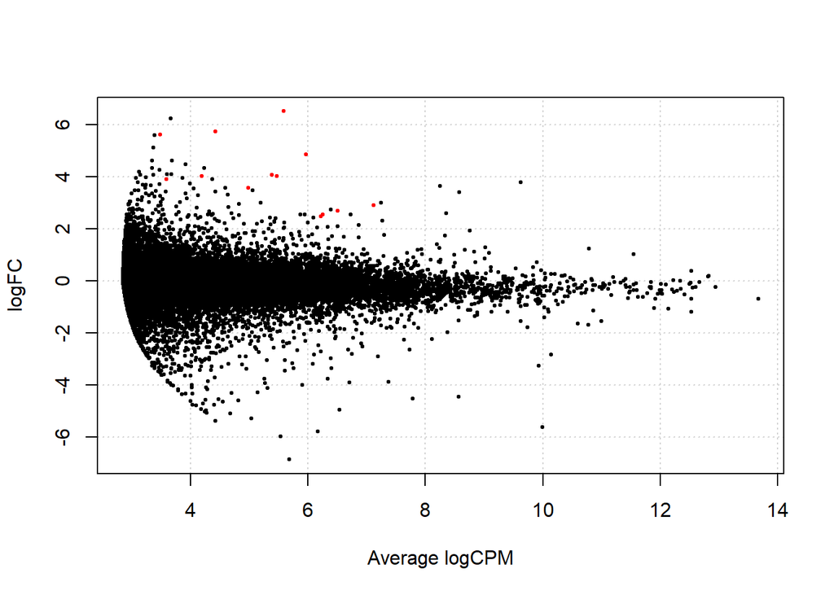

```r
# use smearplot to display DE results
plotSmear(lrt,de.tags = de_called_fdr,cex=0.4)
```

## Integrative analysis

1.Loading the structural variant data.

```r
library(readr)
data_sv <- read_tsv("data/sv_sclc_ucologne_2015.tsv")
dim(data_sv)
```

```
## [1] 50 12
```

```r
# identify the samples that harbours the sv
```

2.Determine the expression level of the gene in the sample that harbours the SV. Among them, we found that some genes influenced by structural variants do not have expression data.

```r
sample_sv <- as.character(data_sv$sample_id) # 50 samples in total
length(sample_sv)
```

```
## [1] 50
```

```r
sample_sv <- unique(sample_sv)
data_expr_sv <- data_trans[,sample_sv] # expression data only contain structural variant sample
dim(data_expr_sv)
```

```
## [1] 18807     2
```

```r
head(colnames(data_expr_sv))
```

```
## [1] "sclc_ucologne_2015_S02297" "sclc_ucologne_2015_S02353"
```

```r
# subtract the sample_id, site1_hugo_symbol, site2_hugo_symbol from the sturctural variant data
data_sv_sub <- data_sv[,c("sample_id","site1_hugo_symbol","site2_hugo_symbol")]
# Create a function to capture the expression of a gene
#' @param data_sv_sub structural variant data
#' @param sample_sv sampleID that harbours the SV, e.g. sample_sv[1]
#' @param data_expr_sv expression data
genexprs_sv <- function(data_sv_sub,sample_sv,data_expr_sv){
  data_sv_sub1 <- data_sv_sub[data_sv_sub$sample_id==sample_sv,]
#data_sv_sub2 <- data_sv_sub[data_sv_sub$sample_id==sample_sv[2],]
# filter the sv gene without expression in the transcriptomic data
sub1_gene_site1_index <- match(as.character(data_sv_sub1$site1_hugo_symbol),rownames(data_expr_sv))
sub1_gene_site2_index <- match(data_sv_sub1$site2_hugo_symbol,rownames(data_expr_sv))
sub1_rm_gene <- c(which(is.na(sub1_gene_site1_index)),which(is.na(sub1_gene_site2_index)))
sub1_gene_site1_index <- sub1_gene_site1_index[-sub1_rm_gene]
sub1_gene_site2_index <- sub1_gene_site2_index[-sub1_rm_gene]
data_sv_sub1 <- data_sv_sub1[-sub1_rm_gene,] # filter the structural variant data
site1_count <- data_expr_sv[sub1_gene_site1_index,sample_sv] # gene expression of site1_hugo_symbol
site2_count <- data_expr_sv[sub1_gene_site2_index,sample_sv] # gene expression of site2_hugo_symbol
exprs_sv <- data.frame(data_sv_sub1,site1_count=site1_count,site2_count=site2_count,row.names = NULL)
return(list(exprs_sv=exprs_sv,site1_index=sub1_gene_site1_index,site2_index=sub1_gene_site2_index))
}
exprs_sv1 <- genexprs_sv(data_sv_sub,sample_sv[1],data_expr_sv)$exprs_sv # return the gene expression of samples with SV
head(exprs_sv1)
```

```
##                   sample_id site1_hugo_symbol site2_hugo_symbol site1_count
## 1 sclc_ucologne_2015_S02297             KDM2A            GLB1L2     8.81532
## 2 sclc_ucologne_2015_S02297            ELMOD1              HPS3     3.96365
## 3 sclc_ucologne_2015_S02297             MTCH2              ODZ4    12.99770
## 4 sclc_ucologne_2015_S02297            TM7SF2             PRRG4    15.71790
## 5 sclc_ucologne_2015_S02297             PPME1             FYCO1    25.23230
## 6 sclc_ucologne_2015_S02297             TAF1D            PIK3CA    33.91920
##   site2_count
## 1    14.65680
## 2     3.48131
## 3     8.01188
## 4    20.63680
## 5     2.88020
## 6     7.08427
```

```r
# For sample: "sclc_ucologne_2015_S02353"
exprs_sv2 <- genexprs_sv(data_sv_sub,sample_sv[2],data_expr_sv)$exprs_sv
```

3.Identify SVs that satisfy the following critiera: (1)The involved pair of genes both have elevated expression levels in samples with the SV compared to samples without the SV. (2)The second gene in the pair is in frame.

```r
# identify the sample without SVs
sample_unsv <- setdiff(colnames(data_trans),sample_sv) # 79 samples without SV
# For "sclc_ucologne_2015_S02297" sample
# step1: gene expression data contain sample without SV
data_trans_unsv <- data_trans[,sample_unsv]
dim(data_trans_unsv)
```

```
## [1] 18807    79
```

```r
# step2: select the second gene in the pair is in frame
data_sv_sub1 <- data_sv[which(data_sv$site2_effect_on_frame=="in-frame" & data_sv$sample_id==sample_sv[1]),]
# step3: extract the  gene expression from sample without SV
#   Filter out genes that do not exist in the gene expression data
tmp1 <- match(data_sv_sub1$site1_hugo_symbol,rownames(data_trans_unsv))
tmp2 <- match(data_sv_sub1$site2_hugo_symbol,rownames(data_trans_unsv))
rm_gene <- c(which(is.na(tmp1)),which(is.na(tmp2)))
if(is.null(rm_gene)==T){
  tmp1 <- tmp1[-rm_gene] # the location of site1 gene in gene expression data
  tmp2 <- tmp2[-rm_gene]# the location of site2 gene in gene expression data
}
# step4: extract site1 and site2 gene expression from data_trans_unsv
data_trans_unsv_site1 <- data_trans_unsv[tmp1,]
dim(data_trans_unsv_site1)
```

```
## [1]  7 79
```

```r
data_trans_unsv_site2 <- data_trans_unsv[tmp2,]
# step5: filter out gene in exprs_sv1 that meet the second critiera
exprs_sv1_f <- exprs_sv1[exprs_sv1$site2_hugo_symbol %in% rownames(data_trans_unsv_site2),] #
head(exprs_sv1_f) # gene expression data with SV
```

```
##                   sample_id site1_hugo_symbol site2_hugo_symbol site1_count
## 1 sclc_ucologne_2015_S02297             KDM2A            GLB1L2    8.815320
## 3 sclc_ucologne_2015_S02297             MTCH2              ODZ4   12.997700
## 5 sclc_ucologne_2015_S02297             PPME1             FYCO1   25.232300
## 6 sclc_ucologne_2015_S02297             TAF1D            PIK3CA   33.919200
## 8 sclc_ucologne_2015_S02297             MYO7A             PSMC3    0.402166
##   site2_count
## 1    14.65680
## 3     8.01188
## 5     2.88020
## 6     7.08427
## 8    20.82650
```

```r
# For the convenience of calculation, the expression matrix is divided into site1 and site2
exprs_sv1_f_site1 <- exprs_sv1_f[,c("sample_id","site1_hugo_symbol","site1_count")]
exprs_sv1_f_site2 <- exprs_sv1_f[,c("sample_id","site2_hugo_symbol","site2_count")]
# step6: compare the gene expression, we have the following variables to compare
# data_trans_unsv_site1: site1 gene expression for sample without SV
# data_trans_unsv_site2: site2 gene expression for sample without SV
# exprs_sv1_f_site1: site1 gene expression for sample with SV
# exprs_sv1_f_site2: site2 gene expression for sample with SV
# 6.1 calculate the mean gene expression of sample without SV
rowmeans_unsv_site1 <- rowMeans(data_trans_unsv_site1)
rowmeans_unsv_site2 <- rowMeans(data_trans_unsv_site2)
# 6.2 compare the gene expression of site1 and site2 individually
which(exprs_sv1_f_site1$site1_count > rowmeans_unsv_site1)
```

```
## TAF1D MYO7A
##     4     5
```

```r
which(exprs_sv1_f_site2$site2_count > rowmeans_unsv_site2)
```

```
## GLB1L2   ODZ4  FYCO1 KLHL18
##      1      2      3      7
```

```r
# 6.3 return the result
```

Transform the code into a function

```r
# identify the sample without SVs
sample_unsv <- setdiff(colnames(data_trans),sample_sv) # 79 samples without SV
#' @param data_sv structural variant data
#' @param sample_sv sampleID that harbours the SV, e.g. sample_sv[1]
#' @param data_trans transcriptomic data
#' @param exprs_sv1 expression data with SV
SVs_selection <- function(data_sv,sample_sv,sample_unsv,data_trans,exprs_sv1){
  # step1: gene expression data contain sample without SV
data_trans_unsv <- data_trans[,sample_unsv]
dim(data_trans_unsv)
# step2: select the second gene in the pair is in frame
data_sv_sub1 <- data_sv[which(data_sv$site2_effect_on_frame=="in-frame" & data_sv$sample_id==sample_sv),]
# step3: extract the  gene expression from sample without SV
#   Filter out genes that do not exist in the gene expression data
tmp1 <- match(data_sv_sub1$site1_hugo_symbol,rownames(data_trans_unsv))
tmp2 <- match(data_sv_sub1$site2_hugo_symbol,rownames(data_trans_unsv))
rm_gene <- c(which(is.na(tmp1)),which(is.na(tmp2)))
if(is.null(rm_gene)==T){
  tmp1 <- tmp1[-rm_gene] # the location of site1 gene in gene expression data
  tmp2 <- tmp2[-rm_gene]# the location of site2 gene in gene expression data
}
# step4: extract site1 and site2 gene expression from data_trans_unsv
data_trans_unsv_site1 <- data_trans_unsv[tmp1,]
dim(data_trans_unsv_site1)
data_trans_unsv_site2 <- data_trans_unsv[tmp2,]
# step5: filter out gene in exprs_sv1 that meet the second critiera
exprs_sv1_f <- exprs_sv1[exprs_sv1$site2_hugo_symbol %in% rownames(data_trans_unsv_site2),] #
head(exprs_sv1_f) # gene expression data with SV
# For the convenience of calculation, the expression matrix is divided into site1 and site2
exprs_sv1_f_site1 <- exprs_sv1_f[,c("sample_id","site1_hugo_symbol","site1_count")]
exprs_sv1_f_site2 <- exprs_sv1_f[,c("sample_id","site2_hugo_symbol","site2_count")]
# step6: compare the gene expression, we have the following variables to compare
# data_trans_unsv_site1: site1 gene expression for sample without SV
# data_trans_unsv_site2: site2 gene expression for sample without SV
# exprs_sv1_f_site1: site1 gene expression for sample with SV
# exprs_sv1_f_site2: site2 gene expression for sample with SV
# 6.1 calculate the mean gene expression of sample without SV
rowmeans_unsv_site1 <- rowMeans(data_trans_unsv_site1)
rowmeans_unsv_site2 <- rowMeans(data_trans_unsv_site2)
# 6.2 compare the gene expression of site1 and site2 individually
a <- which(exprs_sv1_f_site1$site1_count > rowmeans_unsv_site1)
b <- which(exprs_sv1_f_site2$site2_count > rowmeans_unsv_site2)
# 6.3 return the result
result_SV <- exprs_sv1_f[intersect(a,b),c("site1_hugo_symbol","site2_hugo_symbol")]
return(result_SV)
}
cat("The result is as follows.")
```

```
## The result is as follows.
```

```r
SVs_selection(data_sv,sample_sv[1],sample_unsv,data_trans,exprs_sv1)
```

```
## [1] site1_hugo_symbol site2_hugo_symbol
## <0 行> (或0-长度的row.names)
```

```r
SVs_selection(data_sv,sample_sv[2],sample_unsv,data_trans,exprs_sv2)
```

```
##    site1_hugo_symbol site2_hugo_symbol
## 15              EFHB               TYR
## 21             SASH1             SAMD5
```